# Titanic

Machine Learning from Disaster

Juan José Martín y Christian Strasser

```r
library(ggplot2)
library(jsonlite)

titanic_set = read.csv('datasets/train.csv')
```

## Ejercicio 1

**Realizar un análisis descriptivo del dataset: campos, tipos de datos, dimensiones del dataset, etc. y mostrad las 7 primeras filas.**

```r
str(titanic_set)
```

```
## 'data.frame':    891 obs. of  12 variables:
##  $ PassengerId: int  1 2 3 4 5 6 7 8 9 10 ...
##  $ Survived   : int  0 1 1 1 0 0 0 0 1 1 ...
##  $ Pclass     : int  3 1 3 1 3 3 1 3 3 2 ...
##  $ Name       : Factor w/ 891 levels "Abbing, Mr. Anthony",..: 109 191 358 277 16 559 520 629 417 581 ...
##  $ Sex        : Factor w/ 2 levels "female","male": 2 1 1 1 2 2 2 2 1 1 ...
##  $ Age        : num  22 38 26 35 35 NA 54 2 27 14 ...
##  $ SibSp      : int  1 1 0 1 0 0 0 3 0 1 ...
##  $ Parch      : int  0 0 0 0 0 0 0 1 2 0 ...
##  $ Ticket     : Factor w/ 681 levels "110152","110413",..: 524 597 670 50 473 276 86 396 345 133 ...
##  $ Fare       : num  7.25 71.28 7.92 53.1 8.05 ...
##  $ Cabin      : Factor w/ 148 levels "","A10","A14",..: 1 83 1 57 1 1 131 1 1 1 ...
##  $ Embarked   : Factor w/ 4 levels "","C","Q","S": 4 2 4 4 4 3 4 4 4 2 ...
```

```r
names(titanic_set)
```

```
##  [1] "PassengerId" "Survived"    "Pclass"      "Name"        "Sex"
##  [6] "Age"         "SibSp"       "Parch"       "Ticket"      "Fare"
## [11] "Cabin"       "Embarked"
```

```r
summary(titanic_set)
```

```
##   PassengerId       Survived          Pclass
##  Min.   :  1.0   Min.   :0.0000   Min.   :1.000
##  1st Qu.:223.5   1st Qu.:0.0000   1st Qu.:2.000
##  Median :446.0   Median :0.0000   Median :3.000
##  Mean   :446.0   Mean   :0.3838   Mean   :2.309
##  3rd Qu.:668.5   3rd Qu.:1.0000   3rd Qu.:3.000
##  Max.   :891.0   Max.   :1.0000   Max.   :3.000
##
##                                     Name         Sex           Age
##  Abbing, Mr. Anthony                  :  1   female:314   Min.   : 0.42
##  Abbott, Mr. Rossmore Edward          :  1   male  :577   1st Qu.:20.12
##  Abbott, Mrs. Stanton (Rosa Hunt)     :  1                Median :28.00
##  Abelson, Mr. Samuel                  :  1                Mean   :29.70
##  Abelson, Mrs. Samuel (Hannah Wizosky):  1                3rd Qu.:38.00
##  Adahl, Mr. Mauritz Nils Martin       :  1                Max.   :80.00
##  (Other)                              :885                NA's   :177
##      SibSp           Parch             Ticket         Fare
##  Min.   :0.000   Min.   :0.0000   1601    :  7   Min.   :  0.00
##  1st Qu.:0.000   1st Qu.:0.0000   347082  :  7   1st Qu.:  7.91
##  Median :0.000   Median :0.0000   CA. 2343:  7   Median : 14.45
##  Mean   :0.523   Mean   :0.3816   3101295 :  6   Mean   : 32.20
##  3rd Qu.:1.000   3rd Qu.:0.0000   347088  :  6   3rd Qu.: 31.00
##  Max.   :8.000   Max.   :6.0000   CA 2144 :  6   Max.   :512.33
##                                   (Other) :852
##          Cabin     Embarked
##             :687    :  2
##  B96 B98    :  4   C:168
##  C23 C25 C27:  4   Q: 77
##  G6         :  4   S:644
##  C22 C26    :  3
##  D          :  3
##  (Other)    :186
```

```r
head(titanic_set, 7)
```

| PassengerId | Survived | Pclass | Name | Sex | Age | SibSp | Parch | Ticket | Fare | Cabin | Embarked |
| --- | --- | --- | --- | --- | --- | --- | --- | --- | --- | --- | --- |
| 1 | 0 | 3 | Braund, Mr. Owen Harris | male | 22 | 1 | 0 | A/5 21171 | 7.2500 |  | S |
| 2 | 1 | 1 | Cumings, Mrs. John Bradley (Florence Briggs Thayer) | female | 38 | 1 | 0 | PC 17599 | 71.2833 | C85 | C |
| 3 | 1 | 3 | Heikkinen, Miss. Laina | female | 26 | 0 | 0 | STON/O2. 3101282 | 7.9250 |  | S |
| 4 | 1 | 1 | Futrelle, Mrs. Jacques Heath (Lily May Peel) | female | 35 | 1 | 0 | 113803 | 53.1000 | C123 | S |
| 5 | 0 | 3 | Allen, Mr. William Henry | male | 35 | 0 | 0 | 373450 | 8.0500 |  | S |
| 6 | 0 | 3 | Moran, Mr. James | male | NA | 0 | 0 | 330877 | 8.4583 |  | Q |
| 7 | 0 | 1 | McCarthy, Mr. Timothy J | male | 54 | 0 | 0 | 17463 | 51.8625 | E46 | S |

## Ejercicio 2

**Responde a estas breves preguntas:**

- **¿Cuántos hombres había? ¿Cuántas mujeres? Queremos saber la respuesta en valores absolutos y porcentajes.**

El número de hombres y mujeres fue:

```r
t = table(titanic_set$Sex)
t
```

```
##
## female   male
##    314    577
```

Y en porcentaje:

```r
prop.table(t)
```

```
##
##   female     male
## 0.352413 0.647587
```

- **¿Cuántos menores de edad viajaban en el Titanic?**

El número de menos de edad fue:

```r
sum(titanic_set$Age < 18, na.rm=T)
```

```
## [1] 113
```

de los cuales sobrevivieron:

```r
sum(titanic_set$Age < 18 & titanic_set$Survived == 1, na.rm=T)
```

```
## [1] 61
```

- **¿Cuántas personas había entre 20 y 40 años?**

El número de personas entre 20 y 40 años fue:

```r
sum(titanic_set$Age >= 20 & titanic_set$Age <= 40, na.rm=T)
```

```
## [1] 400
```

- **¿Cuántas personas embarcaron en cada puerto?**

Las personas que embarcaron en cada puerto fue:

```r
table(titanic_set$Embarked)
```

```
##
##       C   Q   S
##   2 168  77 644
```

siendo *C = Cherbourg*, *Q = Queenstown* y *S = Southampton*.

## Ejercicio 3

**Realizar las siguientes funciones:**

- **Crea una función que reciba como parámetro un vector y calcule su media (No se puede usar la funcion mean).**

```r
my_mean = function(v) {
  if (typeof(v) == 'character') {
    warning("Vector must be numeric")
    return (NA)
  }
  return (sum(v) / length(v))
}
```

Probamos que la función dé un resultado correcto comparándola con la función *mean* de R:

```r
v = c(1, 3, 6, 3, 8, 5, 4, 4)
mean(v)
```

```
## [1] 4.25
```

```r
my_mean(v)
```

```
## [1] 4.25
```

- **Crea una función que reciba como parámetro dos vectores y nos diga si tienen todos los elementos iguales.**

```r
my_identical = function(v1, v2) {
  if (length(v1) != length(v2)) {
    return (FALSE)
  }

  for (i in 1:length(v1)) {
    if (v1[i] != v2[i] | typeof(v1[i]) != typeof(v2[i])) {
      return (FALSE)
    }
  }

  return (TRUE)
}
```

Probamos que la función dé un resultado correcto comparándola con la función *identical* de R mediante diferentes ejemplos:

```r
v1 = c(1, 3, 6, 3, 8, 5, 4, 4)
v2 = c(1, 3, 6, 3, 8, 5, 4, 4)
identical(v1, v2)
```

```
## [1] TRUE
```

```r
my_identical(v1, v2)
```

```
## [1] TRUE
```

Vectores diferentes:

```r
v3 = c(1, 3, 6, 3, 8, 5, 4, 4)
v4 = c(1, '3', 6, 3, 8, 5, 4, 4)
identical(v3, v4)
```

```
## [1] FALSE
```

```r
my_identical(v3, v4)
```

```
## [1] FALSE
```

Vectores de diferente tamaño:

```r
v5 = c(1, 3, 6, 3, 8, 5, 4, 4)
v6 = c(1, 3, 6, 3, 8, 5, 4)
identical(v5, v6)
```

```
## [1] FALSE
```

```r
my_identical(v5, v6)
```

```
## [1] FALSE
```

- **Crea una función que reciba como parámetro un vector y nos devuelva uno nuevo sin elementos duplicados. P.ej si nos llega el vector *c(2, 1, 3, 4, 5, 5, 4, 1)* la función nos devolverá el vector *c(2, 1, 3, 4, 5)*.**

```r
my_unique = function(v) {
  new_v = c()

  for (i in v) {
    if (!is.element(i, new_v)) {
      new_v = c(new_v, i)
    }
  }

  return (new_v)
}
```

Probamos que la función dé un resultado correcto comparándola con la función *unique* de R:

```r
v = c(1, 3, 6, 3, 8, 4, 4, 64)
unique(v)
```

```
## [1]  1  3  6  8  4 64
```

```r
my_unique(v)
```

```
## [1]  1  3  6  8  4 64
```

## Ejercicio 4

**¿Cuál es el numero medio de parientes de cada pasajero? ¿Qué pasajero tiene mas parientes? ¿Cuántos pasajeros viajaban sin ningún pariente?**

El número medio de parientes era de:

```r
titanic_set$FamRel = rowSums(titanic_set[c('Parch', 'SibSp')], na.rm=TRUE)
mean(titanic_set$FamRel)
```

```
## [1] 0.9046016
```

Los pasajeros con más parientes son:

```r
titanic_set[titanic_set$FamRel == max(titanic_set$FamRel), c('Name', 'Parch', 'SibSp', 'FamRel')]
```

| Name | Parch | SibSp | FamRel |
| --- | --- | --- | --- |
| Sage, Master. Thomas Henry | 2 | 8 | 10 |
| Sage, Miss. Constance Gladys | 2 | 8 | 10 |
| Sage, Mr. Frederick | 2 | 8 | 10 |
| Sage, Mr. George John Jr | 2 | 8 | 10 |
| Sage, Miss. Stella Anna | 2 | 8 | 10 |
| Sage, Mr. Douglas Bullen | 2 | 8 | 10 |
| Sage, Miss. Dorothy Edith "Dolly" | 2 | 8 | 10 |

Estos son 7 de los 9 hermanos (los dos que faltan están en el fichero de test) de la familia Sage, que vinieron con sus padres John George Sage y Annie Elizabeth Cazaly. Para más información sobre esta familia, visita [este link](https://www.encyclopedia-titanica.org/titanic-victim/john-george-sage.html).

El número de pasajeros que viajaban sin parientes fue:

```r
sum(titanic_set$FamRel == 0)
```

```
## [1] 537
```

## Ejercicio 5

**Sustituye las edades que faltan con la media de las edades que ya tenemos.**

```r
mean(titanic_set$Age, na.rm=TRUE)
```

```
## [1] 29.69912
```

```r
age_mean = mean(titanic_set$Age, na.rm=TRUE)
titanic_set[c('Age')][is.na(titanic_set[c('Age')])] = age_mean
```

## Ejercicio 6

**Hablemos del precio de los tickets:**

- **¿Cuál es la mediana del precio de los tickets por clase?**

La mediana del precio de los tickets por clase es:

```r
aggregate(titanic_set$Fare~Pclass, data=titanic_set, FUN=median)
```

| Pclass | titanic_set$Fare |
| --- | --- |
| 1 | 60.2875 |
| 2 | 14.2500 |
| 3 | 8.0500 |

- **¿Cuál el el precio de los tickets que más veces se repite?**

Para sacar el precio de los tickets que más veces se repite podemos usar varias formas a partir de la función *table*.

```r
tt = table(titanic_set$Fare)
```

Por ejemplo, se puede ordenar descendientemente el resultado de la función *table* y comprobar los 10 precios de tickets que más se repite:

```r
tt_sort = sort(tt, decreasing = TRUE)[1:10]
tt_sort
```

```
##
##   8.05     13 7.8958   7.75     26   10.5  7.925  7.775      0 7.2292
##     43     42     38     34     31     24     18     16     15     15
```

Por lo tanto, basta coger el primer elemento para obtener el que más se repite:

```r
names(tt_sort[1])
```

```
## [1] "8.05"
```

Otra forma podría ser esta:

```r
names(tt[tt == max(tt)])
```

```
## [1] "8.05"
```

Y por último:

```r
names(which(tt == max(tt)))
```

```
## [1] "8.05"
```

## Ejercicio 7

**Realiza una (o varias) gráficas en las que se muestre un histograma de la edad de los pasajeros por cada una de las clases. También seria interesante ver una gráfica del número de hombres y mujeres por cada una de las clases.**

El histograma de la edad de los pasajeros por cada una de las clases es el siguiente:

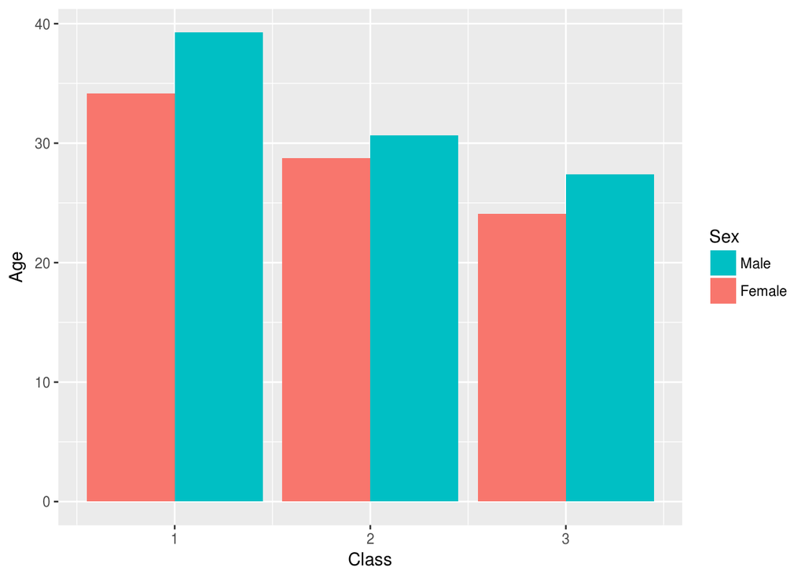

```r
agg = aggregate(Age~Pclass+Sex, data=titanic_set, FUN=mean, na.rm=TRUE)

ggplot(agg, aes(x=Pclass, y=Age, fill=factor(Sex))) +
  geom_bar(stat="identity", position="dodge") +
  scale_fill_discrete(name="Sex",
                      breaks=c("male", "female"),
                      labels=c("Male", "Female")) +
  xlab("Class")+ylab("Age")
```

Los pasajeros más jóvenes pertenecían a la tercera clase y los más mayores a la primera clase, lo cual podría explicarse por ser las personas de mayor edad las que ya habían ganado un status económico-social más alto que los jóvenes.

El histograma del número de hombres y mujeres por cada una de las clases es:

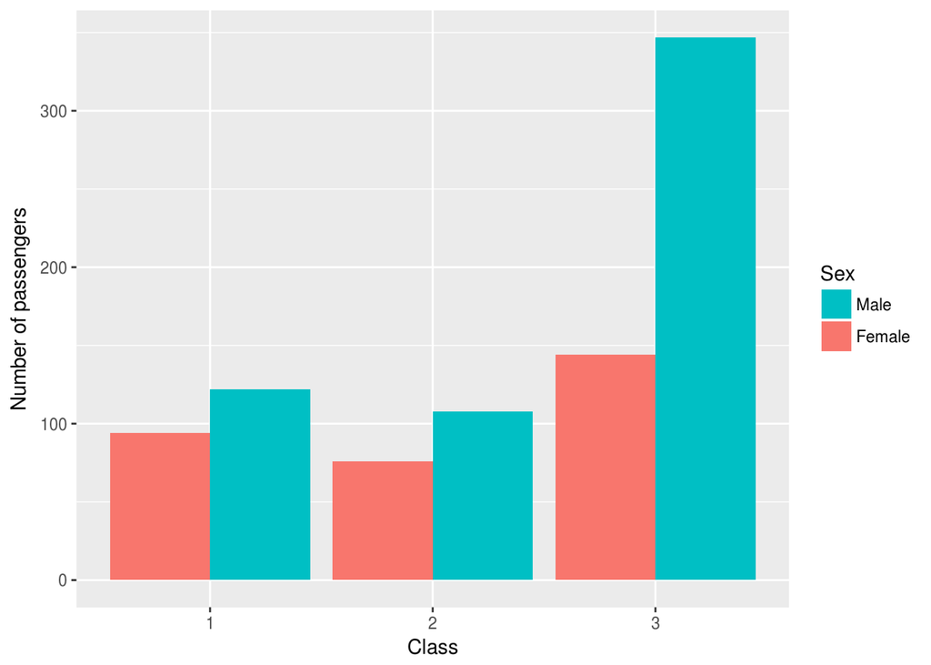

```r
t = table(titanic_set$Pclass, titanic_set$Sex)
t = as.data.frame(t)
colnames(t)=c('Pclass', 'Sex', 'Freq')

ggplot(t, aes(x=Pclass, y=Freq, fill=factor(Sex))) +
  geom_bar(stat="identity", position="dodge") +
  scale_fill_discrete(name="Sex",
                      breaks=c("male", "female"),
                      labels=c("Male", "Female")) +
  xlab("Class")+ylab("Number of passengers")
```

Se puede observar un aumento de más de un 100% en el número de hombres en tercera clase respecto a los que hubo en primera y segunda clase.

## Ejercicio 8

**Realiza la(s) gráfica(s) que puedan mostrar la relación entre la edad de los pasajeros y su probabilidad de supervivencia.**

Para facilitar la interpretación de la gráfica, se ha puesto la edad de cada pasajero en rangos de 5 años.

```r
seq = seq(0, max(titanic_set$Age) + 10, 5)
titanic_set$AgeRange = cut(titanic_set$Age, seq)
titanic_set[1:10, c('Name', 'Sex', 'Age', 'AgeRange')]
```

| Name | Sex | Age | AgeRange |
| --- | --- | --- | --- |
| Braund, Mr. Owen Harris | male | 22.00000 | (20,25] |
| Cumings, Mrs. John Bradley (Florence Briggs Thayer) | female | 38.00000 | (35,40] |
| Heikkinen, Miss. Laina | female | 26.00000 | (25,30] |
| Futrelle, Mrs. Jacques Heath (Lily May Peel) | female | 35.00000 | (30,35] |
| Allen, Mr. William Henry | male | 35.00000 | (30,35] |
| Moran, Mr. James | male | 29.69912 | (25,30] |
| McCarthy, Mr. Timothy J | male | 54.00000 | (50,55] |
| Palsson, Master. Gosta Leonard | male | 2.00000 | (0,5] |
| Johnson, Mrs. Oscar W (Elisabeth Vilhelmina Berg) | female | 27.00000 | (25,30] |
| Nasser, Mrs. Nicholas (Adele Achem) | female | 14.00000 | (10,15] |

La siguiente gráfica se ha hecho de tal forma que se puede apreciar fácilmente la relación entre el sexo del pasajero, su edad y la probabilidad de supervivencia.

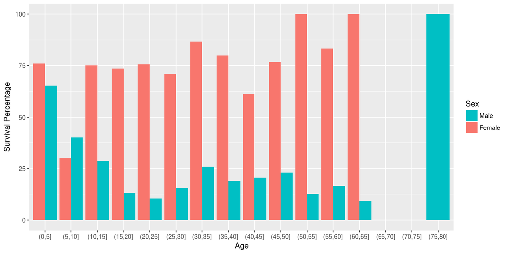

```r
surv_prob = aggregate(Survived~AgeRange+Sex, data=titanic_set, FUN=mean, na.rm=TRUE)
surv_prob$Survived = surv_prob$Survived * 100

ggplot(surv_prob, aes(x=AgeRange,y=Survived,fill=factor(Sex))) +
    geom_bar(stat="identity", position="dodge") +
    scale_fill_discrete(name="Sex",
                        breaks=c("male", "female"),
                        labels=c("Male", "Female")) +
    xlab("Age")+ylab("Survival Percentage")
```

## Ejercicio 9

**Crea un archivo con extensión .json con una lista de todos los pasajeros que contenga: nombre, clase y edad. Valida que está correctamente formado cargándolo en R.**

Escribimos el JSON:

```r
x = toJSON(titanic_set[,c('Name', 'Pclass', 'Age')])
write(x, file="json_test.json")
```

Y lo leemos:

```r
y = fromJSON("json_test.json")
head(y)
```

| Name | Pclass | Age |
| --- | --- | --- |
| Braund, Mr. Owen Harris | 3 | 22.0000 |
| Cumings, Mrs. John Bradley (Florence Briggs Thayer) | 1 | 38.0000 |
| Heikkinen, Miss. Laina | 3 | 26.0000 |
| Futrelle, Mrs. Jacques Heath (Lily May Peel) | 1 | 35.0000 |
| Allen, Mr. William Henry | 3 | 35.0000 |
| Moran, Mr. James | 3 | 29.6991 |

## Ejercicio 10

**¿Qué conclusiones has podido sacar a partir del trabajo con este dataset? Para justificar tu decisión puedes demostrar tus predicciones usando el conjunto de test.**